# Week 09 Mid-Project Data Check-In

- Show All Code
- Hide All Code
- View Source

CSC3107 Information Visualization

Author

Team SlateBlue

Published

July 17, 2026

## 1. Data Source Description

### 1.1 Fossil Carbon Emissions Data

| **Dataset** | National Fossil Carbon Emissions 2024 v1.0 |
| --- | --- |
| **Source** | Global Carbon Project (GCB 2024) |
| **Dataset URL** | https://globalcarbonbudget.org/gcb-2024/ |
| **News article** | https://www.carbonbrief.org/analysis-global-co2-emissions-will-reach-new-high-in-2024-despite-slower-growth/ |
| **File** | `National_Fossil_Carbon_Emissions_2024v1.0-1.xlsx` |

The original visualization appeared in a Carbon Brief article published in November 2024, which projected that 2024 global fossil CO₂ emissions would reach a record 37.4 GtCO₂. The underlying dataset contains **confirmed figures from 1850 to 2023** only and the 2024 value shown in the article was a preliminary estimate, not part of the dataset. Our redesign therefore covers the confirmed range of 1959–2023.

Values are reported in **million tonnes of carbon per year (MtC/yr)**. We convert to **billion tonnes of CO₂ per year (GtCO₂/yr)** using the factor 1 MtC = 3.664 MtCO₂ (as documented in the dataset).

We use the **“Territorial Emissions”** sheet, which records emissions produced within each country’s borders (excluding land-use change and consumption-based transfers).

The raw Excel file is included in `data/raw/` and the cleaned CSV outputs are in `data/cleaned/`.

### 1.2 Population Data

| **Dataset** | World Development Indicators — Total Population |
| --- | --- |
| **Source** | World Bank, based on United Nations World Population Prospects |
| **URL** | https://data.worldbank.org/indicator/SP.POP.TOTL |
| **File** | `API_SP.POP.TOTL_DS2_en_excel_v2_417154.xls` |

This dataset provides annual total population by country from 1960 to 2023. It will be used to compute **per-capita CO₂ emissions** (tonnes CO₂ per person) for each region, addressing the critique that the original chart shows only absolute totals and overstates the responsibility of high-population countries like China.

The dataset includes a pre-aggregated “European Union” row, which we use directly instead of summing individual EU member states.

## 2. Data Import and Cleaning Pipeline

### 2.1 Load Packages

```r
library(tidyverse)
library(readxl)
library(scales)
```

### 2.2 Import Raw Data

The emissions Excel file has several header rows with metadata (citation info, unit descriptions, notes on methodology) before the actual data begins. We skip the first 11 rows to land directly on the data, where each row is a year and each column is a country.

```r
emissions_raw <- read_excel(
  "data/raw/National_Fossil_Carbon_Emissions_2024v1.0-1.xlsx",
  sheet = "Territorial Emissions",
  skip = 11
)

# First column is the year (unnamed in Excel)
names(emissions_raw)[1] <- "year"

cat(
  "Raw dataset:",
  nrow(emissions_raw),
  "rows x",
  ncol(emissions_raw),
  "columns\n"
)
```

```
Raw dataset: 174 rows x 231 columns
```

```r
cat(
  "Year range:",
  min(emissions_raw$year, na.rm = TRUE),
  "-",
  max(emissions_raw$year, na.rm = TRUE),
  "\n"
)
```

```
Year range: 1850 - 2023
```

### 2.3 Define Regions

```r
col_names <- names(emissions_raw)

# Key country columns (verified from the dataset's column names after skip = 11)
china_col <- "China"
india_col <- "India"
usa_col <- "USA"
world_col <- "World"

# Read EU-27 member states from the Regions sheet of the dataset
regions_sheet <- read_excel(
  "data/raw/National_Fossil_Carbon_Emissions_2024v1.0-1.xlsx",
  sheet = "Regions",
  col_names = c("region_name", "countries")
)

eu27_string <- regions_sheet |>
  filter(region_name == "EU27") |>
  pull(countries)

eu27_countries <- str_trim(str_split(eu27_string, ",")[[1]])

cat("EU-27 countries from Regions sheet:", length(eu27_countries), "\n")
```

```
EU-27 countries from Regions sheet: 27
```

```r
# Match EU-27 columns in the Territorial Emissions data
eu27_cols <- eu27_countries[eu27_countries %in% col_names]

cat(
  "EU-27 columns matched:",
  length(eu27_cols),
  "of",
  length(eu27_countries),
  "\n"
)
```

```
EU-27 columns matched: 27 of 27
```

```r
if (length(eu27_cols) < length(eu27_countries)) {
  cat("Missing:", setdiff(eu27_countries, eu27_cols), "\n")
}
```

### 2.4 Clean and Aggregate

The raw data is in MtC/yr (million tonnes of carbon), but climate reporting typically uses GtCO₂/yr (billion tonnes of CO₂). We apply the conversion factor documented in the dataset itself: multiply by 3.664 to convert carbon to CO₂, then divide by 1000 to go from million to billion tonnes. “Rest of World” is not a column in the dataset so we compute it by subtracting the four named regions from the World total, which ensures all emissions are accounted for.

```r
# Keep only rows with valid numeric years
emissions_clean <- emissions_raw |>
  filter(!is.na(year)) |>
  mutate(year = as.numeric(year)) |>
  filter(!is.na(year))

# Conversion factor: MtC/yr -> GtCO2/yr
MTC_TO_GTCO2 <- 3.664 / 1000

# Aggregate regions
emissions_regions <- emissions_clean |>
  rowwise() |>
  mutate(
    china_gtco2 = ifelse(
      !is.na(.data[[china_col]]),
      as.numeric(.data[[china_col]]) * MTC_TO_GTCO2,
      0
    ),
    india_gtco2 = ifelse(
      !is.na(.data[[india_col]]),
      as.numeric(.data[[india_col]]) * MTC_TO_GTCO2,
      0
    ),
    usa_gtco2 = ifelse(
      !is.na(.data[[usa_col]]),
      as.numeric(.data[[usa_col]]) * MTC_TO_GTCO2,
      0
    ),
    world_gtco2 = ifelse(
      !is.na(.data[[world_col]]),
      as.numeric(.data[[world_col]]) * MTC_TO_GTCO2,
      0
    ),
    eu27_gtco2 = sum(
      across(all_of(eu27_cols), ~ ifelse(is.na(.x), 0, as.numeric(.x))),
      na.rm = TRUE
    ) *
      MTC_TO_GTCO2
  ) |>
  ungroup() |>
  mutate(
    rest_of_world_gtco2 = world_gtco2 -
      china_gtco2 -
      india_gtco2 -
      usa_gtco2 -
      eu27_gtco2
  ) |>
  select(
    year,
    china_gtco2,
    india_gtco2,
    usa_gtco2,
    eu27_gtco2,
    rest_of_world_gtco2,
    world_gtco2
  ) |>
  filter(year >= 1959, year <= 2023)

cat("Cleaned dataset:", nrow(emissions_regions), "rows (1959-2023)\n")
```

```
Cleaned dataset: 65 rows (1959-2023)
```

### 2.5 Pivot to Long Format

The wide format (one column per region) is useful for computation, but for plotting with `ggplot2` we need a long format where each row represents one region in one year. We also compute each region’s percentage share of the global total at this stage, since we plan to include a % share chart in our redesign.

```r
emissions_long <- emissions_regions |>
  pivot_longer(
    cols = c(
      china_gtco2,
      india_gtco2,
      usa_gtco2,
      eu27_gtco2,
      rest_of_world_gtco2
    ),
    names_to = "region",
    values_to = "emissions_gtco2"
  ) |>
  mutate(
    region = case_match(
      region,
      "china_gtco2" ~ "China",
      "india_gtco2" ~ "India",
      "usa_gtco2" ~ "United States",
      "eu27_gtco2" ~ "European Union",
      "rest_of_world_gtco2" ~ "Rest of World"
    ),
    region = factor(
      region,
      levels = c(
        "China",
        "United States",
        "European Union",
        "India",
        "Rest of World"
      )
    ),
    pct_share = emissions_gtco2 / world_gtco2 * 100
  )
```

### 2.6 Save Cleaned Data

```r
write_csv(emissions_regions, "data/cleaned/emissions_wide.csv")
write_csv(emissions_long, "data/cleaned/emissions_by_region.csv")

cat("Saved: data/cleaned/emissions_wide.csv\n")
```

```
Saved: data/cleaned/emissions_wide.csv
```

```r
cat("Saved: data/cleaned/emissions_by_region.csv\n")
```

```
Saved: data/cleaned/emissions_by_region.csv
```

### 2.7 Import Population Data

One of our main critiques of the original chart is that it only shows absolute emissions, which makes China look like the biggest contributor by far. But China also has the largest population, and we believe if you look at emissions per person, the picture can changes significantly. To build a per-capita view, we need population data for each region, which we get the data from the World Bank.

```r
pop_raw <- read_excel(
  "data/raw/API_SP.POP.TOTL_DS2_en_excel_v2_417154.xls",
  sheet = "Data",
  skip = 3
)

cat("Population dataset:", nrow(pop_raw), "rows x", ncol(pop_raw), "columns\n")
```

```
Population dataset: 266 rows x 70 columns
```

### 2.8 Clean and Merge Population Data

Conveniently, the World Bank dataset already has pre-aggregated rows for “China”, “India”, “United States”, “European Union”, and “World”, so we do not need to sum individual countries ourselves. We compute “Rest of World” population by subtracting the four named regions from the World total, the same approach we used for emissions.

```r
pop_regions <- pop_raw |>
  filter(
    `Country Name` %in%
      c(
        "China",
        "India",
        "United States",
        "European Union",
        "World"
      )
  ) |>
  select(`Country Name`, matches("^\\d{4}$")) |>
  pivot_longer(
    cols = -`Country Name`,
    names_to = "year",
    values_to = "population"
  ) |>
  mutate(year = as.numeric(year)) |>
  filter(year >= 1960, year <= 2023) |>
  rename(country = `Country Name`)

# Map World Bank names to our region names and compute Rest of World
pop_wide <- pop_regions |>
  pivot_wider(names_from = country, values_from = population) |>
  mutate(
    `Rest of World` = World - China - India - `United States` - `European Union`
  ) |>
  select(-World) |>
  pivot_longer(
    cols = -year,
    names_to = "region",
    values_to = "population"
  )

cat("Population data:", nrow(pop_wide), "rows\n")
```

```
Population data: 320 rows
```

```r
cat("Year range:", min(pop_wide$year), "-", max(pop_wide$year), "\n")
```

```
Year range: 1960 - 2023
```

### 2.9 Compute Per-Capita Emissions

We join the emissions and population data by region and year, then divide total emissions by population to get tonnes of CO₂ per person. Note that our emissions data starts at 1959, but the World Bank population data only starts at 1960, so the merged dataset begins at 1960 (we lose just one year). The per-capita figures confirm what we expected: the US emits far more per person than China, despite China having higher total emissions.

```r
emissions_percapita <- emissions_long |>
  inner_join(pop_wide, by = c("region", "year")) |>
  mutate(
    # GtCO2 -> tonnes CO2 per person
    emissions_per_capita = (emissions_gtco2 * 1e9) / population
  )

cat("Merged dataset:", nrow(emissions_percapita), "rows\n")
```

```
Merged dataset: 320 rows
```

```r
cat(
  "Year range:",
  min(emissions_percapita$year),
  "-",
  max(emissions_percapita$year),
  "\n\n"
)
```

```
Year range: 1960 - 2023
```

```r
# Show 2023 per-capita values
emissions_percapita |>
  filter(year == 2023) |>
  arrange(desc(emissions_per_capita)) |>
  mutate(
    emissions_per_capita = round(emissions_per_capita, 2),
    population_m = round(population / 1e6, 0)
  ) |>
  select(region, emissions_per_capita, population_m) |>
  knitr::kable(
    col.names = c("Region", "tCO2/person (2023)", "Population (millions)"),
    caption = "Per-capita emissions by region (2023)"
  )
```

Per-capita emissions by region (2023)

| Region | tCO2/person (2023) | Population (millions) |
| --- | --- | --- |
| United States | 14.58 | 337 |
| China | 8.44 | 1411 |
| European Union | 5.59 | 449 |
| Rest of World | 3.48 | 4430 |
| India | 2.13 | 1438 |

```r
write_csv(emissions_percapita, "data/cleaned/emissions_percapita.csv")
cat("Saved: data/cleaned/emissions_percapita.csv\n")
```

```
Saved: data/cleaned/emissions_percapita.csv
```

### 2.10 Quick Validation

As a sanity check, we verify two things:

1. Our computed 2023 global total should be around 37.8 GtCO₂ based on the Carbon Brief article on the 2023 confirmed figure
2. The World Bank’s pre-aggregated “European Union” population matches the sum of the 27 individual member states, so we know we are using the correct EU definition.

```r
# --- Check 1: Global emissions total ---
total_2023 <- emissions_regions |>
  filter(year == 2023) |>
  pull(world_gtco2)
cat(
  "2023 global total:",
  round(total_2023, 2),
  "GtCO2",
  "(expected ~37.8 GtCO2)\n\n"
)
```

```
2023 global total: 37.79 GtCO2 (expected ~37.8 GtCO2)
```

```r
# --- Check 2: EU population aggregation ---
eu27_pop_names <- c(
  "Austria",
  "Belgium",
  "Bulgaria",
  "Croatia",
  "Cyprus",
  "Czechia",
  "Denmark",
  "Estonia",
  "Finland",
  "France",
  "Germany",
  "Greece",
  "Hungary",
  "Ireland",
  "Italy",
  "Latvia",
  "Lithuania",
  "Luxembourg",
  "Malta",
  "Netherlands",
  "Poland",
  "Portugal",
  "Romania",
  "Slovak Republic",
  "Slovenia",
  "Spain",
  "Sweden"
)

eu27_pop_sum <- pop_raw |>
  filter(`Country Name` %in% eu27_pop_names) |>
  pull(`2023`) |>
  as.numeric() |>
  sum(na.rm = TRUE)

eu_pop_agg <- pop_raw |>
  filter(`Country Name` == "European Union") |>
  pull(`2023`) |>
  as.numeric()

cat(
  "EU population check (2023):\n",
  " Sum of 27 member states:",
  format(eu27_pop_sum, big.mark = ","),
  "\n",
  " Pre-aggregated EU row:  ",
  format(eu_pop_agg, big.mark = ","),
  "\n",
  " Match:",
  eu27_pop_sum == eu_pop_agg,
  "\n"
)
```

```
EU population check (2023):
  Sum of 27 member states: 448,897,545
  Pre-aggregated EU row:   448,897,545
  Match: TRUE
```

```r
# Show latest year per region
emissions_long |>
  filter(year == 2023) |>
  arrange(desc(emissions_gtco2)) |>
  mutate(
    emissions_gtco2 = round(emissions_gtco2, 2),
    pct_share = round(pct_share, 1)
  ) |>
  select(region, emissions_gtco2, pct_share) |>
  knitr::kable(
    col.names = c("Region", "GtCO2 (2023)", "% of Global"),
    caption = "2023 emissions by region"
  )
```

2023 emissions by region

| Region | GtCO2 (2023) | % of Global |
| --- | --- | --- |
| Rest of World | 15.40 | 40.8 |
| China | 11.90 | 31.5 |
| United States | 4.91 | 13.0 |
| India | 3.06 | 8.1 |
| European Union | 2.51 | 6.6 |

## 3. Design Brief

This redesign targets **general-public readers of climate news** who want to compare which countries drive CO₂ emissions growth. The goal is to show both **total** and **per-capita emissions** so readers can assess national responsibility on a fair basis.

## 4. Planned Design Direction

The biggest problem with the original chart is that it uses a stacked area format, which means only China (the bottom layer) is actually readable while for every other region, you have to mentally subtract between two wobbly lines to figure out the value, which is really hard to do accurately. So for our redesign, we are replacing it completely.

From the Week 5 feedback, we took away a few key points that are shaping our design:

1. **Use distinct colours, not a gradient.** The original uses different shades of blue for all regions, but since these are categorical (not ordered), they should be clearly distinguishable. We switched to the Okabe–Ito palette, which is also colorblind-friendly.
2. **Sparkline summary table.** This was suggested during the feedback and we think it is a strong fit for our data. It lets us show the trend, latest total emissions, per-capita emissions, % share, and % change for each region all in one compact table. This is likely going to be the centrepiece of our poster.
3. **Show per-capita data.** The original chart only shows total emissions, which makes China look like the biggest contributor by far. But when we calculated per-capita figures using World Bank population data, we found that the US emits about 14 tCO₂/person compared to China’s 8 tCO₂/person. We want our redesign to show both views so readers can make fairer comparisons.
4. **Show % share instead of stacking.** Rather than using a stacked area for “Rest of World”, we plan to show each region’s share as a percentage line chart, which makes proportional changes much easier to read.

We have drafted a few different chart options (see Section 5 below) and would appreciate feedback on which combination would work best on the poster alongside the sparkline table.

## 5. Draft Visualizations (Work in Progress)

The drafts below show that our data pipeline works end-to-end and give a sense of where we are heading. These are not final, we will refine the styling and layout before the poster.

### 5.1 Sparkline Summary Table (Main Visualization)

This will be the centrepiece of our poster. It combines trend lines, total emissions, per-capita values, % share, and % change into a single compact table which makes it easy to compare all five regions at a glance.

```r
library(gt)
library(gtExtras)

spark_data <- emissions_percapita |>
  group_by(region) |>
  summarise(
    trend = list(emissions_gtco2),
    latest = round(last(emissions_gtco2), 2),
    per_capita = round(last(emissions_per_capita), 1),
    share = paste0(round(last(pct_share), 1), "%"),
    change_5yr = round(
      (last(emissions_gtco2) - nth(emissions_gtco2, -5)) /
        nth(emissions_gtco2, -5) *
        100,
      1
    ),
    .groups = "drop"
  ) |>
  arrange(desc(latest))

spark_data |>
  gt() |>
  gt_plt_sparkline(
    trend,
    same_limit = FALSE,
    type = "shaded",
    fig_dim = c(15, 40),
    palette = c("black", "black", "grey80", "grey80", "grey90")
  ) |>
  cols_label(
    region = "Region",
    trend = "Trend (1960–2023)",
    latest = "GtCO2 (2023)",
    per_capita = "tCO2/person",
    share = "% Share",
    change_5yr = "5yr Change (%)"
  ) |>
  tab_header(
    title = "Fossil CO2 Emissions by Region",
    subtitle = "Summary with embedded sparklines (1960–2023)"
  ) |>
  fmt_number(columns = latest, decimals = 2) |>
  fmt_number(columns = per_capita, decimals = 1) |>
  fmt_number(columns = change_5yr, decimals = 1, force_sign = TRUE) |>
  tab_source_note("Data: Global Carbon Project (GCB 2024) & World Bank") |>
  tab_style(
    style = cell_text(weight = "bold"),
    locations = cells_column_labels()
  )
```

Fossil CO2 Emissions by Region

Summary with embedded sparklines (1960–2023)

| Region | Trend (1960–2023) | GtCO2 (2023) | tCO2/person | % Share | 5yr Change (%) |
| --- | --- | --- | --- | --- | --- |
| Rest of World |  | 15.40 | 3.5 | 40.8% | −1.3 |
| China |  | 11.90 | 8.4 | 31.5% | +11.1 |
| United States |  | 4.91 | 14.6 | 13% | −6.7 |
| India |  | 3.06 | 2.1 | 8.1% | +17.2 |
| European Union |  | 2.51 | 5.6 | 6.6% | −13.6 |

Data: Global Carbon Project (GCB 2024) & World Bank

Figure 1

### 5.2 Per-Capita Emissions (Supporting Chart)

This is the chart we plan to pair with the sparkline table on the poster. It tells a very different story from the original as the US has consistently been the highest per-capita emitter, even though China leads in total emissions. This crossover is hard to see in the sparkline table alone since each region is on a separate row.

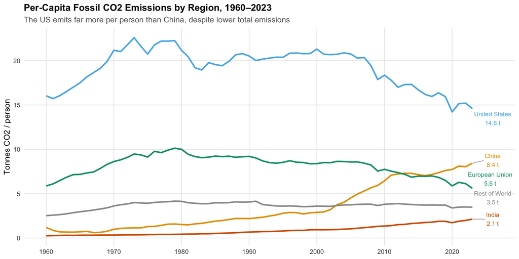

Figure 2: Draft: Per-capita fossil CO2 emissions (tonnes CO2/person), 1960–2023.

```r
library(ggrepel)

region_colors <- c(
  "China" = "#E69F00",
  "United States" = "#56B4E9",
  "European Union" = "#009E73",
  "India" = "#D55E00",
  "Rest of World" = "#999999"
)

label_pc <- emissions_percapita |>
  filter(year == max(year))

ggplot(
  emissions_percapita,
  aes(x = year, y = emissions_per_capita, color = region)
) +
  geom_line(linewidth = 1) +
  geom_text_repel(
    data = label_pc,
    aes(label = paste0(region, "\n", round(emissions_per_capita, 1), " t")),
    nudge_x = 3,
    size = 3,
    direction = "y",
    segment.color = "grey70"
  ) +
  scale_color_manual(values = region_colors) +
  scale_x_continuous(breaks = seq(1960, 2020, 10)) +
  labs(
    title = "Per-Capita Fossil CO2 Emissions by Region, 1960–2023",
    subtitle = "The US emits far more per person than China, despite lower total emissions",
    x = NULL,
    y = "Tonnes CO2 / person"
  ) +
  theme_minimal(base_size = 11) +
  theme(
    plot.title = element_text(face = "bold", size = 13),
    plot.subtitle = element_text(color = "grey40"),
    panel.grid.minor = element_blank(),
    legend.position = "none"
  )
```

### 5.3 Other Draft Explorations

The charts below are additional views we explored. We are not planning to include these on the poster, but they helped us understand the data and may be useful as supplementary material.

#### Total Emissions by Region (Faceted Line Chart)

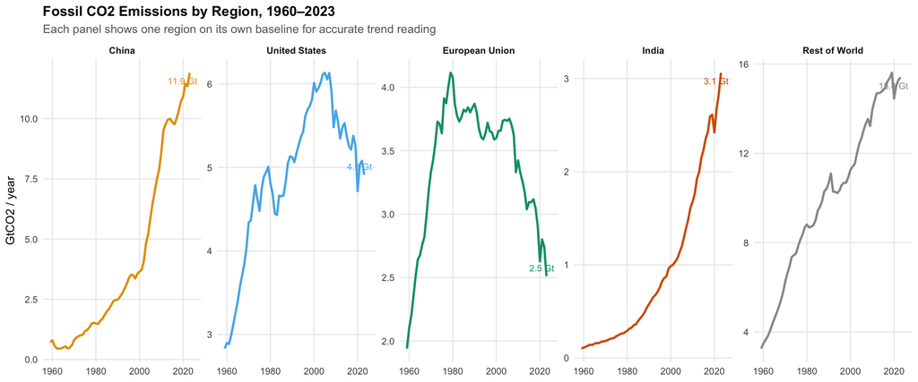

Figure 3: Draft: Fossil CO2 emissions by region (GtCO2/yr), 1960–2023.

```r
label_data <- emissions_long |>
  filter(year == max(year))

ggplot(emissions_long, aes(x = year, y = emissions_gtco2, color = region)) +
  geom_line(linewidth = 1) +
  geom_text_repel(
    data = label_data,
    aes(label = paste0(round(emissions_gtco2, 1), " Gt")),
    nudge_x = 2,
    size = 3,
    direction = "y",
    segment.color = "grey70"
  ) +
  facet_wrap(~region, nrow = 1, scales = "free_y") +
  scale_color_manual(values = region_colors) +
  scale_x_continuous(breaks = seq(1960, 2020, 20)) +
  labs(
    title = "Fossil CO2 Emissions by Region, 1960–2023",
    subtitle = "Each panel shows one region on its own baseline for accurate trend reading",
    x = NULL,
    y = "GtCO2 / year"
  ) +
  theme_minimal(base_size = 11) +
  theme(
    plot.title = element_text(face = "bold", size = 13),
    plot.subtitle = element_text(color = "grey40"),
    strip.text = element_text(face = "bold"),
    panel.grid.minor = element_blank(),
    legend.position = "none"
  )
```

#### Percentage Share of Global Emissions

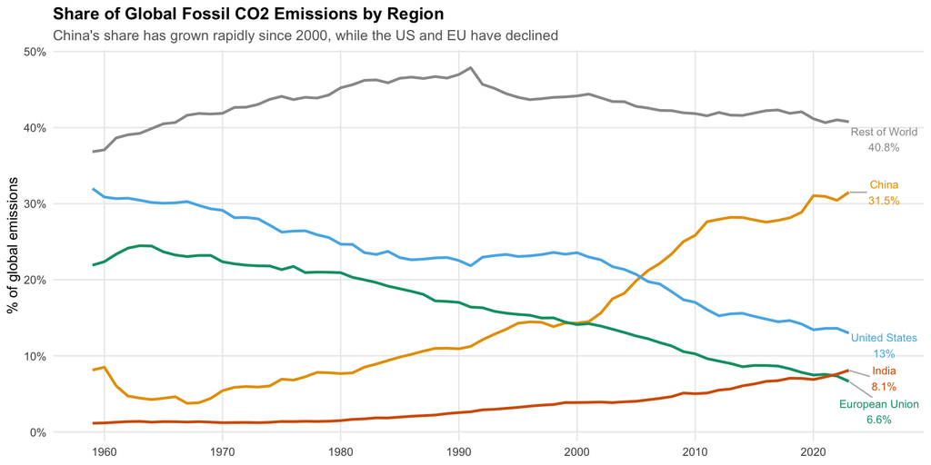

Figure 4: Draft: Each region’s share of global fossil CO2 emissions (%), 1960–2023.

```r
label_pct <- emissions_long |>
  filter(year == max(year))

ggplot(emissions_long, aes(x = year, y = pct_share, color = region)) +
  geom_line(linewidth = 1) +
  geom_text_repel(
    data = label_pct,
    aes(label = paste0(region, "\n", round(pct_share, 1), "%")),
    nudge_x = 3,
    size = 3,
    direction = "y",
    segment.color = "grey70"
  ) +
  scale_color_manual(values = region_colors) +
  scale_x_continuous(breaks = seq(1960, 2020, 10)) +
  scale_y_continuous(labels = label_percent(scale = 1)) +
  labs(
    title = "Share of Global Fossil CO2 Emissions by Region",
    subtitle = "China's share has grown rapidly since 2000, while the US and EU have declined",
    x = NULL,
    y = "% of global emissions"
  ) +
  theme_minimal(base_size = 11) +
  theme(
    plot.title = element_text(face = "bold", size = 13),
    plot.subtitle = element_text(color = "grey40"),
    panel.grid.minor = element_blank(),
    legend.position = "none"
  )
```